# iDEP: Pathway Analysis

## If this site has contributed to your work, please cite our article:

Ge, S.X., Son, E.W. & Yao, R. iDEP: an integrated web application for differential expression and pathway analysis of RNA-Seq data. BMC Bioinformatics 19, 534 (2018). https://doi.org/10.1186/s12859-018-2486-6

## Summary

Read Counts data were analyzed using iDEP v2.4.4. The data was first filtered to remove reads below 0.5 CPM in at least 1 sample. Then the data was transformed with EdgeR using a pseudocount of 4. Missing values were imputed using geneMedian. Genes are classified as differly expressed based on having a p-value below 0.1 and log fold change above 2.

The contrast **Radiation_Dose_cGy10000-Radiation_Dose_cGy0** was evaluated against the **KEGG** gene-set collection, restricting pathway sizes to 5-2000 genes. Pathways were tested with the **GSEA (Pre-Ranked)** workflow, applying a pathway FDR cutoff of **0.1** and filtering genes with DEG FDR greater than **1**. Absolute fold values were not applied, preserving directional fold changes.

Heatmap previews focus on the selected significant pathways: Path:ath03460 Fanconi anemia pathway

This document contains the generated plots and the full set of user-selected parameters for reproducibility.

## Analysis Settings

| Setting | Value |
| --- | --- |
| Contrast | Radiation_Dose_cGy10000-Radiation_Dose_cGy0 |
| Gene-set collection | KEGG |
| Method | GSEA (Pre-Ranked) |
| Pathways displayed | 20 |
| Pathway size filter | 5 - 2000 |
| Pathway FDR cutoff | 0.1 |
| Gene-level FDR cutoff | 1 |
| Absolute fold filter | Disabled |
| Heatmap palette | Green-Black-Red |
| KEGG palette | Blue-Red |

**Show all parameter values**

```
printcode : TRUE
go : KEGG
select_org : 644
my_range : 5, 2000
select_contrast : Radiation_Dose_cGy10000-Radiation_Dose_cGy0
min_set_size : 5
max_set_size : 2000
gene_p_val_cutoff : 1
absolute_fold : FALSE
pathway_p_val_cutoff : 0.1
n_pathway_show : 20
pathway_method : 3
heatmap_color_select : Green-Black-Red
kegg_color_select : Blue-Red
kegg_colors : c("green", "red"), c("red", "green"), c("blue", "red"), c("green", "magenta"), c("blue", "orange")
show_pathway_id : FALSE
```

## Gene Sets

The statement below confirms whether a curated gene-set collection was available for this run.

```r
# Display gene sets information from params
if (!is.null(params$gene_sets) && length(params$gene_sets) > 0) {
  print(paste("Loaded", length(params$gene_sets), "gene sets from", params$go))
} else {
  print("No gene sets available.")
}
```

```
## [1] "Loaded 143 gene sets from KEGG"
```

## Pathway analysis for contrast: Radiation_Dose_cGy10000-Radiation_Dose_cGy0

The tables or heatmaps below mirror the visuals from the Pathway tab while preserving the selected enrichment algorithm.

```r
# Display GAGE results from pre-computed data
if (params$pathway_method == 1 && !is.null(params$pathway_list_data) && nrow(params$pathway_list_data) > 0) {
  kbl(params$pathway_list_data) %>%
    kable_classic(full_width = F, html_font = "Cambria")
} else if (params$pathway_method == 1) {
  print("No GAGE pathway data available.")
}
```

```r
if (params$pathway_method == 2) {
  # only remove pathway ID for Ensembl species
  show_pathway_id <- params$show_pathway_id
  # always show pathway ID for STRING species
  if (params$select_org < 0) {
    show_pathway_id <- TRUE
  }
  plot_pgsea(
    my_range = c(params$min_set_size, params$max_set_size),
    processed_data = params$pre_processed,
    contrast_samples = params$contrast_samples,
    gene_sets = params$gene_sets,
    pathway_p_val_cutoff = params$pathway_p_val_cutoff,
    n_pathway_show = params$n_pathway_show,
    select_go = params$go,
    show_pathway_id = show_pathway_id,
    margin = c(3, 1, 13, 20)
  )
}
```

```r
if (params$pathway_method == 4) {
  # only remove pathway ID for Ensembl species
  show_pathway_id <- params$show_pathway_id
  # always show pathway ID for STRING species
  if (params$select_org < 0) {
    show_pathway_id <- TRUE
  }
  pgsea_plot_all(
    go = params$go,
    my_range = c(params$min_set_size, params$max_set_size),
    data = params$pre_processed,
    select_contrast = params$contrast_samples,
    gene_sets = params$gene_sets,
    pathway_p_val_cutoff = params$pathway_p_val_cutoff,
    n_pathway_show = params$n_pathway_show,
    select_go = params$go,
    show_pathway_id = show_pathway_id,
    margin = c(3, 1, 13, 20)
  )
}
```

```r
if (params$pathway_method %in% c(6:8)) {
  gsva_algorithm <- switch(
    as.numeric(params$pathway_method) - 5,
    "gsva",   #6
    "ssgsea", #7
    "plage"   #8
  )

  # only remove pathway ID for Ensembl species
  show_pathway_id <- params$show_pathway_id
  # always show pathway ID for STRING species
  if (params$select_org < 0) {
    show_pathway_id <- TRUE
  }

    plot_gsva(
      my_range = c(params$min_set_size, params$max_set_size),
      processed_data = params$pre_processed,
      contrast_samples = params$contrast_samples,
      gene_sets = params$gene_sets,
      pathway_p_val_cutoff = params$pathway_p_val_cutoff,
      n_pathway_show = params$n_pathway_show,
      select_go = params$go,
      show_pathway_id = show_pathway_id,
      algorithm = gsva_algorithm
    )
}
```

```r
# Display FGSEA results from pre-computed data
if (params$pathway_method == 3 && !is.null(params$pathway_list_data) && nrow(params$pathway_list_data) > 0) {
  kbl(params$pathway_list_data) %>%
    kable_classic(full_width = F, html_font = "Cambria")
} else if (params$pathway_method == 3) {
  print("No FGSEA pathway data available.")
}
```

|  | Direction | Pathways | NES | nGenes | adj_p_val | Genes |
| --- | --- | --- | --- | --- | --- | --- |
| 119 | Up | Homologous recombination | 0.7501 | 57 | 0.0056 | chr31, R…. |
| 137 | Up | Plant-pathogen interaction | 0.5602 | 196 | 0.018 | CNGC10, …. |
| 121 | Up | Fanconi anemia pathway | 0.7203 | 43 | 0.061 | RECQ4A, …. |
| 130 | Up | Protein processing in endoplasmic reticulum | 0.5175 | 201 | 0.061 | CUL2, AT…. |
| 113 | Up | Polycomb repressive complex | 0.6942 | 48 | 0.078 | UBP2, SK…. |

## Tree

Related pathways are clustered to highlight shared gene membership and biological themes.

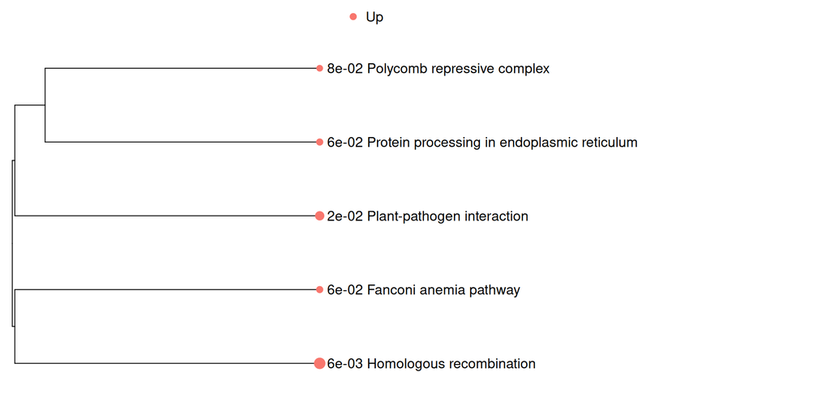

## Network plot

The enrichment network reveals how significant pathways overlap; edge width reflects shared genes while node color follows group assignments from the Pathway tab.

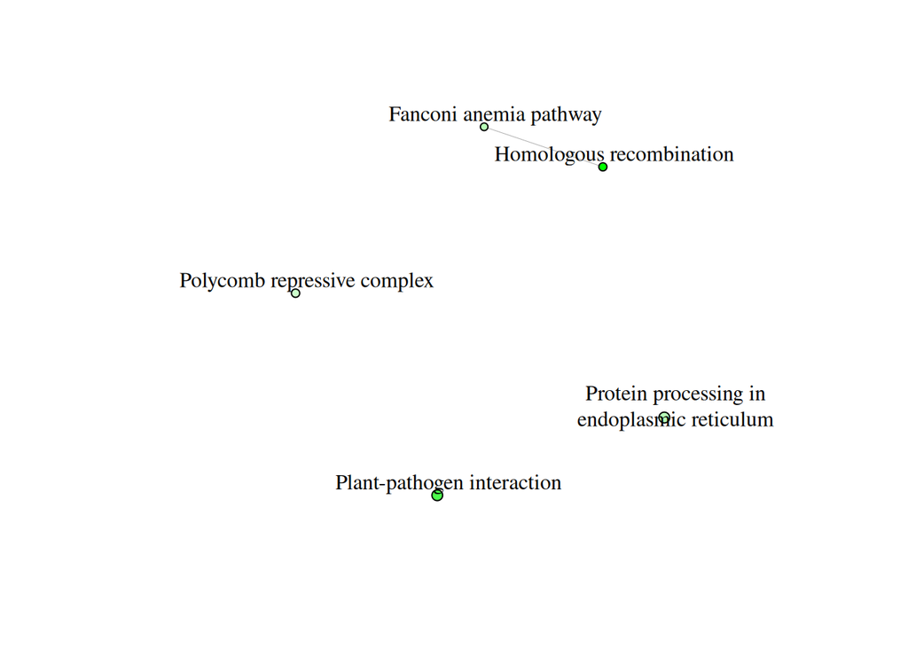

[interactive chart not shown]

```r
if (!is.null(params$pathway_list_data) && nrow(params$pathway_list_data) > 0) {
  network_data <- idepGolem::network_data(
    network = params$pathway_list_data,
    up_down_reg_deg = params$up_down_reg_deg,
    wrap_text_network_deg = params$wrap_text_network_deg,
    layout_vis_deg = params$layout_vis_deg,
    edge_cutoff_deg = params$edge_cutoff_deg,
    group_color = params$group_color
  )
  idepGolem::vis_network_plot(
    network_data = network_data
  )
} else {
  print("No pathway data available for network plot.")
}
```

## Heatmap

When a pathway is selected on the Heatmap tab, the corresponding genes are displayed with the chosen palette and clustering settings.

```r
if (!is.null(params$sig_pathways)) {
  params$sig_pathways
}
```

```
## [1] "Path:ath03460 Fanconi anemia pathway"
```

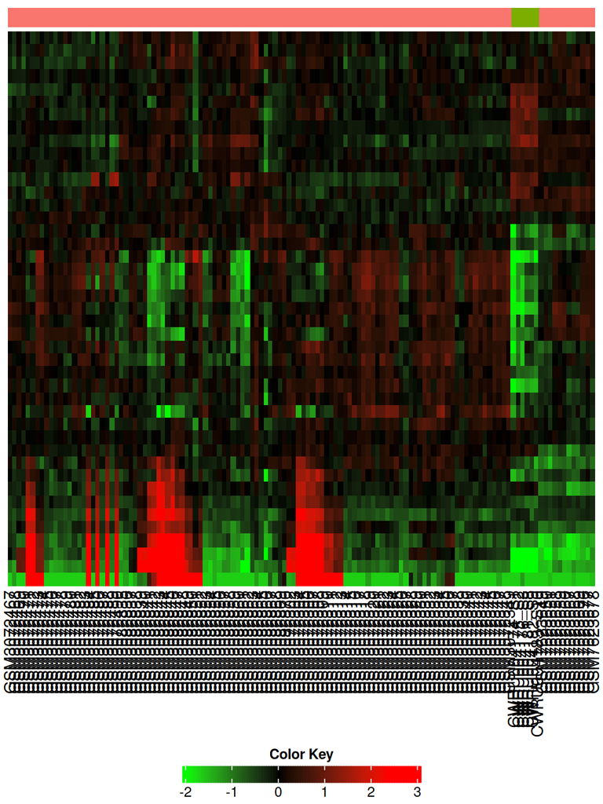

```r
if(!is.null(params$sig_pathways) && !is.null(params$selected_pathway_data)) {
  deg_heatmap(
    df = params$selected_pathway_data,
    bar = NULL,
    heatmap_color_select = unlist(strsplit(params$heatmap_color_select, "-")),
    cluster_rows = TRUE
  )
} else {
  print("Heatmap not available (select a pathway on the Heatmap tab first).")
}
```

## KEGG pathway

For KEGG-based analyses, highlighted pathways are rendered with the chosen low/high color scale to overlay log2 fold-change statistics.

```
## Path:ath03460 Fanconi anemia pathway
```

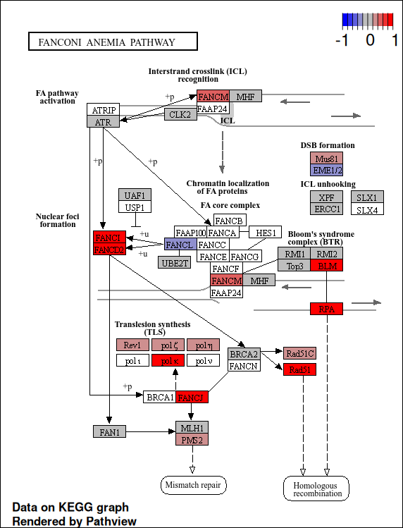

```r
if (!is.null(params$pathway_list_data) &&
    ncol(params$pathway_list_data) >= 5 &&
    !is.null(params$sig_pathways_kegg) &&
    params$go == "KEGG") {
  out_image <- kegg_pathway(
    go = params$go,
    gage_pathway_data = params$pathway_list_data[, 1:5],
    sig_pathways = params$sig_pathways_kegg,
    select_contrast = params$select_contrast,
    limma = params$limma,
    converted = params$converted,
    idep_data = params$idep_data,
    select_org = params$select_org,
    low_color = params$kegg_colors[[params$kegg_color_select]][1],
    high_color = params$kegg_colors[[params$kegg_color_select]][2]
  )
  cat(params$sig_pathways_kegg, "\n")
  if (!is.null(out_image$src) && file.exists(out_image$src)) {
    knitr::include_graphics(out_image$src)
  } else {
    message("KEGG pathway image unavailable; file was not created.")
  }
} else {
  print("KEGG pathway visualization not available (requires KEGG database selection).")
}
```

```r
# This chunk is deprecated - pathway results are displayed above
# pathway_method == 0 is not used in current version
```

Generated using iDEP v2.4.4 (https://bioinformatics.sdstate.edu/idep). 2026-06-14 21:41:21 UTC. Accuracy not guaranteed.